# R Club - *decontam*

Yasmin Hilliam, PhD

4/4/2024

### Package set up

Install and load required packages

```r
if (!require("BiocManager", quietly = TRUE))
  install.packages("BiocManager")
BiocManager::install()
```

```r
n
```

```r
BiocManager::install(pkgs = c("tidyverse","phyloseq","decontam"))
```

```r
n
```

```r
library(tidyverse)
library(phyloseq)
library(decontam)
```

### Plot theme set up

Sets up a global theme for all plots created during this session

```r
theme_set(theme_bw()) # set global theme to bw
theme_replace(axis.title.x=element_text(size=14), # set individual theme options for plotting
              axis.title.y=element_text(size=14,angle=90),
              axis.text.x=element_text(size=12),
              axis.text.y=element_text(size=12),
              legend.title=element_text(size=14),
              legend.text=element_text(size=12))
```

### Import data

Read in necessary data sets for creation of *phyloseq* object

```r
read.csv("R.Club.counts.csv",
         row.names = 1) -> counts # import 16S count data

head(counts)
```

|  | cont1 | cont3 | cont4 | cont5 | cont6 | cont7 | cont8 | cont9 | cont10 | cont11 | cont12 | cont13 | cont14 | cont15 | cont16 | cont17 | cont18 | samp1 | samp4 | samp2 | samp3 | samp5 | samp27 | samp30 | samp28 | samp29 | samp31 | samp23 | samp21 | … |
| --- | --- | --- | --- | --- | --- | --- | --- | --- | --- | --- | --- | --- | --- | --- | --- | --- | --- | --- | --- | --- | --- | --- | --- | --- | --- | --- | --- | --- | --- | --- |
| 37f9d95d321438477967281dcfa4efc1 | 25 | 30 | 50 | 0 | 0 | 59 | 74 | 0 | 117 | 77 | 32 | 133 | 16 | 0 | 71 | 78 | 95 | 175614 | 259956 | 262204 | 168896 | 158542 | 108377 | 167948 | 140219 | 164906 | 165090 | 76 | 40059 | … |
| cf0b071a6c4379929a752da49f50d82d | 0 | 0 | 0 | 32 | 48 | 0 | 55 | 89 | 86 | 0 | 0 | 117 | 0 | 37 | 46 | 0 | 87 | 136729 | 206443 | 207807 | 132604 | 123379 | 86936 | 136437 | 110680 | 131376 | 130454 | 79 | 30796 | … |
| 0fa481957525a80964121165c280f20f | 15 | 0 | 0 | 14 | 15 | 0 | 41 | 48 | 0 | 0 | 16 | 0 | 0 | 0 | 0 | 37 | 100 | 123 | 0 | 84 | 400 | 52 | 96 | 67 | 34 | 0 | 60 | 81 | 64 | … |
| c1f3db7b438bb005b1a070738d34b223 | 0 | 8 | 16 | 0 | 0 | 26 | 0 | 0 | 87 | 23 | 0 | 89 | 0 | 0 | 46 | 0 | 0 | 113 | 76 | 0 | 316 | 0 | 82 | 0 | 0 | 60 | 0 | 0 | 0 | … |
| 46f53a2cfdbbcab346718fa49070a734 | 0 | 0 | 0 | 0 | 0 | 0 | 31 | 0 | 56 | 0 | 0 | 72 | 0 | 100 | 67 | 0 | 0 | 32 | 0 | 0 | 33 | 40 | 0 | 33 | 0 | 0 | 39 | 128 | 0 | … |
| e67e77e1bd9027aabdad51ff3c4ad69a | 0 | 0 | 0 | 0 | 0 | 23 | 0 | 0 | 0 | 0 | 0 | 0 | 0 | 64 | 62 | 0 | 51 | 0 | 50 | 52 | 0 | 0 | 34 | 0 | 33 | 59 | 0 | 0 | 40 | … |

```r
read.csv("R.Club.metadata.csv") -> metadata # import sample metadata

head(metadata)
```

|  | index | sample_or_control | quant |
| --- | --- | --- | --- |
| 1 | samp1 | sample | 7.76 |
| 2 | samp2 | sample | 28.80 |
| 3 | samp3 | sample | 1.60 |
| 4 | samp4 | sample | 20.00 |
| 5 | samp5 | sample | 0.86 |
| 6 | samp6 | sample | 4.20 |

```r
read.csv("R.Club.taxonomy.csv",
         row.names = 1) -> taxonomy # import taxonomy file

head(taxonomy)
```

|  | kingdom | phylum | class | order | family | genus |
| --- | --- | --- | --- | --- | --- | --- |
| 37f9d95d321438477967281dcfa4efc1 | Bacteria | Firmicutes | Bacilli | Staphylococcales | Staphylococcaceae | Staphylococcus |
| cf0b071a6c4379929a752da49f50d82d | Bacteria | Firmicutes | Bacilli | Staphylococcales | Staphylococcaceae | Staphylococcus |
| 0fa481957525a80964121165c280f20f | Bacteria | Proteobacteria | Gammaproteobacteria | Pseudomonadales | Pseudomonadaceae | Pseudomonas |
| c1f3db7b438bb005b1a070738d34b223 | Bacteria | Proteobacteria | Gammaproteobacteria | Pseudomonadales | Pseudomonadaceae | Pseudomonas |
| 46f53a2cfdbbcab346718fa49070a734 | Bacteria | Firmicutes | Bacilli | Lactobacillales | Streptococcaceae | Streptococcus |
| e67e77e1bd9027aabdad51ff3c4ad69a | Bacteria | Firmicutes | Bacilli | Lactobacillales | Streptococcaceae | Streptococcus |

### Combine dataframes using *phyloseq*

Create *phyloseq* object from imported data sets

```r
samp <- metadata # copy metadata object to new samp object

rownames(samp) <- metadata$index # set index column as rownames

taxonomy <- as.matrix(taxonomy) # convert taxonomny dataframe to matrix

asv <- otu_table(counts, taxa_are_rows = TRUE) # generate otu table object
samp <- sample_data(samp) # generate sample data object
tax <- tax_table(taxonomy) # generate taxonomy table object

ps <- merge_phyloseq(asv,samp,tax) # merge into phyloseq object

sample_data(ps) # check sample data element of phyloseq object
```

```
Sample Data:        [391 samples by 3 sample variables]:
```

|  | index | sample_or_control | quant |
| --- | --- | --- | --- |
| cont1 | cont1 | control | 0.005 |
| cont3 | cont3 | control | 0.005 |
| cont4 | cont4 | control | 0.005 |
| cont5 | cont5 | control | 0.005 |
| cont6 | cont6 | control | 0.005 |
| cont7 | cont7 | control | 0.005 |
| cont8 | cont8 | control | 0.005 |
| cont9 | cont9 | control | 0.005 |
| cont10 | cont10 | control | 0.005 |
| cont11 | cont11 | control | 0.005 |

[output cut: 381 more lines]

```r
ps # check dimensions of phyloseq object
```

```
phyloseq-class experiment-level object
otu_table()   OTU Table:         [ 11516 taxa and 391 samples ]
sample_data() Sample Data:       [ 391 samples by 3 sample variables ]
tax_table()   Taxonomy Table:    [ 11516 taxa by 6 taxonomic ranks ]
```

### Convert *phyloseq* data back into dataframe

Allows us to manipulate data outside of *phyloseq*

```r
sd <- as.data.frame(sample_data(ps)) # put sample_data into ggplot friendly data frame

sd$librarysize <- sample_sums(ps) #generate librarysize column - by summing read counts
```

### Plot library size

Visualize which samples have small or large library sizes

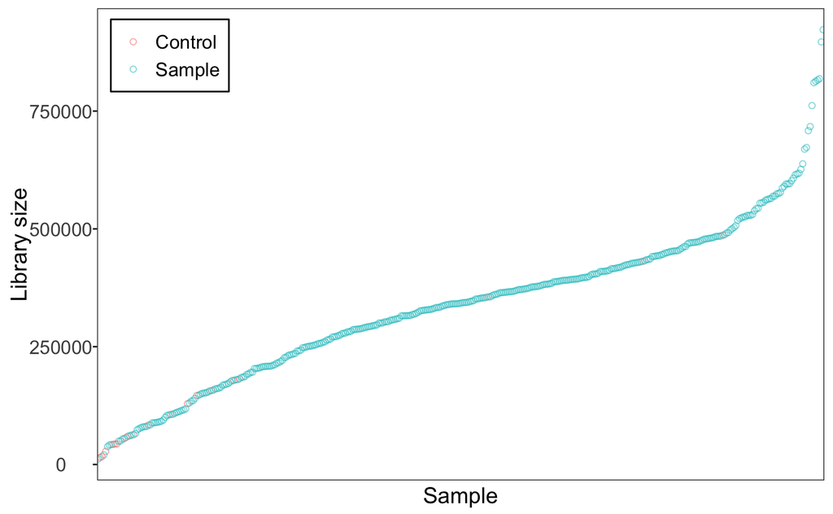

```r
ggplot(data = sd, # input dataframe
       aes(x = reorder(index,librarysize), # set x axis - reorder sample by ascending library size
           y = librarysize, # set y axis
           color = sample_or_control)) + # set color of points
  geom_point(shape = 1,
             alpha = 0.5) + # change point size
  ylab("Library size") + # relabel y axis
  xlab("Sample") + # relabel x acis
  scale_color_discrete(labels = c("Control","Sample")) + # relabel legend categories
  theme(axis.text.x = element_blank(), # change vertical justification
        axis.ticks.x = element_blank(), # remove x axis ticks
        panel.grid.minor = element_blank(), # remove minor gridlines
        panel.grid.major = element_blank(), # remove major gridlines
        legend.title = element_blank(), # remove legend title
        legend.position = c(0.1,0.9), # move legend
        legend.background = element_rect(color = "black")) # set outer boundary of legend box
```

### Identify contaminants by frequency

This method uses the distribution of the frequency of each ASV and the corresponding sample DNA concentration to identify contaminants

```r
contamdfFreq <- isContaminant(ps, # input phyloseq object
                              method = "frequency", # define method for contaminant identification
                              conc = "quant") # name column containing DNA concentration information

head(contamdfFreq)
```

|  | freq | prev | p.freq | p.prev | p | contaminant |
| --- | --- | --- | --- | --- | --- | --- |
| 37f9d95d321438477967281dcfa4efc1 | 0.14263417 | 372 | 1.0000000 | NA | 1.0000000 | FALSE |
| cf0b071a6c4379929a752da49f50d82d | 0.11392757 | 354 | 1.0000000 | NA | 1.0000000 | FALSE |
| 0fa481957525a80964121165c280f20f | 0.06863230 | 314 | 1.0000000 | NA | 1.0000000 | FALSE |
| c1f3db7b438bb005b1a070738d34b223 | 0.05405337 | 256 | 1.0000000 | NA | 1.0000000 | FALSE |
| 46f53a2cfdbbcab346718fa49070a734 | 0.03752105 | 282 | 0.4614528 | NA | 0.4614528 | FALSE |
| e67e77e1bd9027aabdad51ff3c4ad69a | 0.02954344 | 223 | 0.5105987 | NA | 0.5105987 | FALSE |

```r
table(contamdfFreq$contaminant)
```

```
FALSE  TRUE
11485    31
```

Through the “frequency” method, 31 of our 11516 ASVs have been called as contaminants. Here, we used the default probability threshold for rejection of the null hypothesis which is 0.1.

### Activity - how is the number of contaminants called affected by making the model more or less stringent?

```r
contamdfFreqThr <- isContaminant(ps,
                                 method = "frequency",
                                 conc = "quant",
                                 threshold = 0.05) # change probability threshold to examine changes in contaminants

table(contamdfFreqThr$contaminant)
```

```
FALSE  TRUE
11504    12
```

Now that we’ve seen how the model uses its probability threshold, let’s take a closer look at the identified contaminants to see how the program is deciding which ASVs are contaminants based on frequency and DNA concentration.

### Plot frequency vs. DNA conc.

```r
which(contamdfFreq$contaminant) # identify which ASVs are contaminants in our dataframe
```

```
 [1]  416  451  491  511  605  663  693  800  852 1001 1181 1296 1381 1395 1779 1788 1844 1930 1956
[20] 2037 2040 2589 2664 3434 3460 3599 4032 4207 4380 4431 9391
```

Fortunately, none of the identified contaminants are among the ASVs with the highest frequency in our dataset. Let’s plot an identified non-contaminant [1] alongside an identified contaminant [2037] to see how their distributions compare.

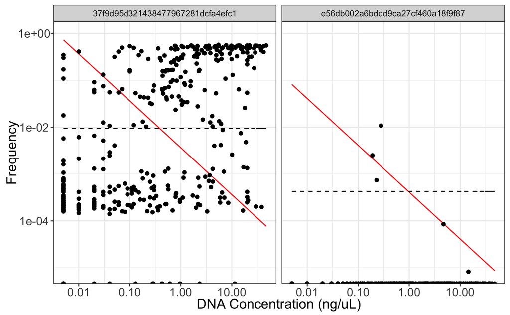

```r
plot_frequency(ps,
               taxa_names(ps)[c(1,2037)],
               conc="quant") +
  xlab("DNA Concentration (ng/uL)")
```

The dashed black line shows a model of a non-contaminant ASV whose frequency will be independent of DNA concentration. The red line shows the expected correlation of a contaminant ASV whose frequency will be inversely proportional to DNA concentration. Which plot represents a contaminant and which represents a non-contaminant?

### Identify contaminants through prevalence

*decontam* also provides a method for identifying contaminants through their presence and absence in known samples and controls. This method does not take into account the DNA concentrations of samples, just whether or not they are identified as sample or control in the metadata.

```r
sample_data(ps)$is.neg <- sample_data(ps)$sample_or_control == "control" # create new variable in phyloseq object that identifies negative controls based on sample_or_control column

contamdfPrev <- isContaminant(ps, # input phyloseq object
                               method = "prevalence", # define method for contaminant identification
                               neg = "is.neg") # define column for identifying negative controls

table(contamdfPrev$contaminant)
```

```
FALSE  TRUE
11445    71
```

```r
contamdfPrevThr <- isContaminant(ps, # input phyloseq object
                                 method = "prevalence", # define method for contaminant identification
                                 neg = "is.neg", # define column for identifying negative controls
                                 threshold = 0.5) # define threshold for contaminant identification

table(contamdfPrevThr$contaminant)
```

```
FALSE  TRUE
11403   113
```

# Plot ASV prevalence in samples vs. controls

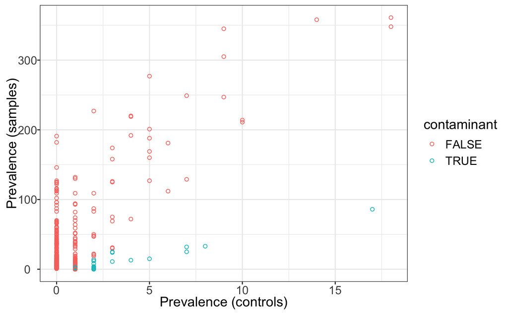

```r
psPrev <- transform_sample_counts(ps,
                                function(abund) 1*(abund>0)) # transform sample counts

psPrev.neg <- prune_samples(sample_data(psPrev)$sample_or_control == "control",
                            psPrev) # make list of controls

psPrev.pos <- prune_samples(sample_data(psPrev)$sample_or_control == "sample",
                            psPrev) # make list of samples

dfPrev <- data.frame(prevPos = taxa_sums(psPrev.pos), # build dataframe
                     prevNeg = taxa_sums(psPrev.neg),
                     contaminant = contamdfPrev$contaminant)

ggplot(data = dfPrev, # input dataframe
       aes(x = prevNeg, # x axis prevalence in negative controls
           y = prevPos, # y axis prevalence in samples
           color = contaminant)) +
  geom_point(shape = 1) +
  xlab("Prevalence (controls)") +
  ylab("Prevalence (samples)")
```

This plot is generated from the contaminants identified using the default threshold of 0.1. However, there are a couple of concerning ASVs in this plot. Which points would you be concerned about if this were your data? Let’s create the same plot but this time using our more stringent calling threshold of 0.5.

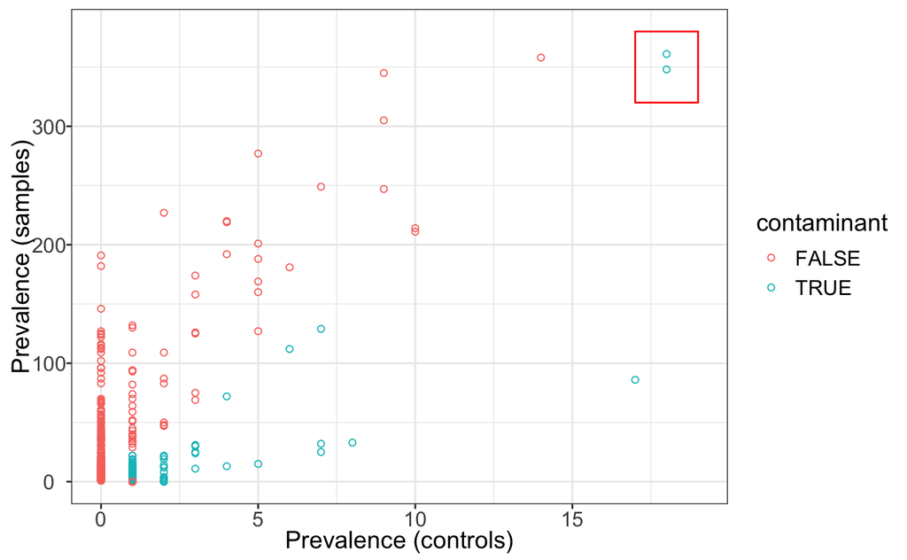

```r
dfPrevThr <- data.frame(prevPos = taxa_sums(psPrev.pos),
                        prevNeg = taxa_sums(psPrev.neg),
                        contaminant = contamdfPrevThr$contaminant) # change which data set contaminants are called from to the one generated with our more stringent threshold

ggplot(data = dfPrevThr, # input dataframe
       aes(x = prevNeg, # x axis prevalence in negative controls
           y = prevPos, # y axis prevalence in samples
           color = contaminant)) +
  geom_point(shape = 1) +
  annotate("rect", # add rectangle to highlight points
           xmin = 17, # x axis start point
           xmax = 19, # x axis end point
           ymin = 320, # y axis start point
           ymax = 380, # y axis end point
           fill = NA, # no fill
           color = "red") + # red border
  xlab("Prevalence (controls)") + # x axis label
  ylab("Prevalence (samples)") # y axis label
```

Now we can see that the two ASVs of concern have been called as contaminants. In the case of this data, a more stringent calling method may be better suited for identifying contaminants. Now we need to filter identified contaminants from our *phyloseq* object.

### Remove contaminants for downstream analysis

```r
ps # check dimensions of current phyloseq object
```

```
phyloseq-class experiment-level object
otu_table()   OTU Table:         [ 11516 taxa and 391 samples ]
sample_data() Sample Data:       [ 391 samples by 4 sample variables ]
tax_table()   Taxonomy Table:    [ 11516 taxa by 6 taxonomic ranks ]
```

```r
psNoncontam <- prune_taxa(!contamdfPrevThr$contaminant,
                          ps)

# contaminant is a Boolean variable so using an exclamation point tells phyloseq not to select ASVs which have TRUE in the contaminant column for taxa pruning

psNoncontam # check dimensions of new phyloseq object
```

```
phyloseq-class experiment-level object
otu_table()   OTU Table:         [ 11403 taxa and 391 samples ]
sample_data() Sample Data:       [ 391 samples by 4 sample variables ]
tax_table()   Taxonomy Table:    [ 11403 taxa by 6 taxonomic ranks ]
```

Voila! Now we have contaminant-free data that can be carried forward into further analysis.

## Activities

### Combined models

Prevalence and frequency are the two basic models by which *decontam* identifies contaminants. However, the package also offers models that combine both methods.

1. Run the help command to open the *decontam* manual and read about the other available methods.

```r
?isContaminant
```

2. Identify contaminants using the “both” method. How many contaminants are identified using this method?
3. Generate a plot of prevalence in controls vs. samples. Does the “both” method seem suitable for this dataset? Why?

When using methods that combine both frequency and prevalence calculations, you can provide a vector with a length of two to the threshold argument: the first value sets the threshold for the frequency test and the second value sets the threshold for the prevalence test. Using the “either” method, attempt to optimise these values. Plot prevalence in samples vs. controls to check that ASVs of concern are being correctly identified as contaminants.

4. Identify contaminants using “either” method
5. Plot prevalence in samples vs. controls